# MBA em Gestão Estratégica em Banking - In Company Banrisul - UNISINOS

- Estatística e econometria para gestão de risco de crédito e da formação da carteira de investimentos
- Ano/Semestre: 2020/1
- Professor: Prof. Msc. Davi Souza Simon

### Status

- Revisão de conceitos básicos - ok!
- Estatística Descritiva - ok!
- Teste de Hipóteses - ok!
- Regressão Linear - Conclusão de Exercício
- Regressão Logística - Hoje!
- R e RStudio - ok!

### Análises Longitudinais (Cross Section) - Exemplo

Exercício:

- Preparar modelo de regressão múltipla, para melhorar o poder explicativo da relação entre FCF e FCI. Nosso objetivo final é explicar o fluxo de caixa de investimento das empresas.
- Em um trabalho científico, usualmente buscamos na teoria ou na literatura empírica variáveis já reportadas como explicadoras da relação em análise.
- Para entregar por e-mail o script.

### Análises Longitudinais (Cross Section) - Exemplo

```r
nomes <- c("Ordem","Nome","Classe","Bolsa","Codigo","tipo_de_ativo","setor_NAICS"
           ,"Setor_economatica","setor_Bovespa","SubsetorBovespa","SegmentoBovespa"
           ,"Particip_no_indice","Segmento_Listagem","AT","DivPagto"
           , "LucroLiq","PtLqCo1","ValorMercado","EnterpriseValue","VPA","ROA"
           ,"ROE_ini","ROE_med","PrincAcionista", "Percent_Princ_Acio","Beta"
           ,"Div_p_acao", "CNPJ","ROE_final", "Cx_Oper", "Cx_Invest", "Cx_Financ"
           , "PtLqCo2", "Pat_Liq")
```

### Análises Longitudinais (Cross Section) - Exemplo

```r
Dados_2016 <- read_excel("Dados 2016.xlsx",sheet=1, col_names = TRUE,
                         col_types = NULL, na = "-", skip = 0)
colnames(Dados_2016) <- nomes
Dados_2016 <- filter(Dados_2016, !is.na(Dados_2016$Segmento_Listagem))
Dados_2016_Fin <- filter(Dados_2016, Setor_economatica=="Finanças e Seguros")
Dados_2016_N_Fin <- filter(Dados_2016, !Setor_economatica=="Finanças e Seguros")
Dados_2016_N_Fin <- mutate(Dados_2016_N_Fin,
  FCO_sAT = Cx_Oper / AT,
  FCI_sAT = Cx_Invest*-1 / AT,
  FCF_sAT = Cx_Financ / AT,
  TAM = log(AT),
  ALAV = AT/Pat_Liq
  )
Dados_2016_N_Fin <- filter(Dados_2016_N_Fin, !is.na(AT))
```

### Análises Longitudinais (Cross Section) - Exemplo

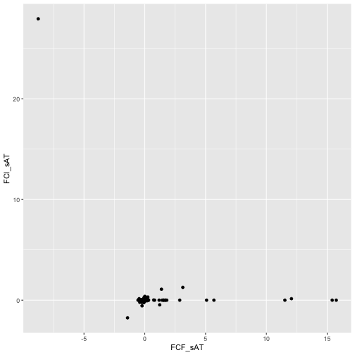

```r
ggplot(data=Dados_2016_N_Fin) + geom_point(aes(x=FCF_sAT, y=FCI_sAT))
```

### Análises Longitudinais (Cross Section) - Exemplo

```r
which.max(Dados_2016_N_Fin$FCI_sAT)
```

```
[1] 4
```

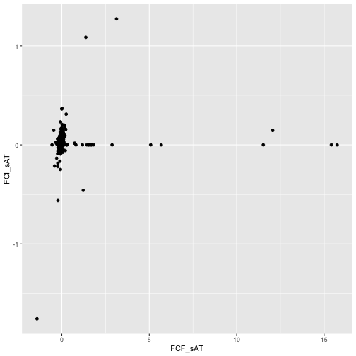

```r
Dados_2016_N_Fin <- Dados_2016_N_Fin[-4,]
ggplot(data=Dados_2016_N_Fin) + geom_point(aes(x=FCF_sAT, y=FCI_sAT))
```

### Análises Longitudinais (Cross Section) - Exemplo

```r
install.packages("robustHD", repos = "http://cran.us.r-project.org")
library(robustHD)
```

### Análises Longitudinais (Cross Section) - Exemplo

```r
Dados_2016_N_Fin$FCO_sAT <- winsorize(Dados_2016_N_Fin$FCO_sAT, prob=0.9999)
Dados_2016_N_Fin$FCI_sAT <- winsorize(Dados_2016_N_Fin$FCI_sAT, prob=0.9999)
Dados_2016_N_Fin$FCF_sAT <- winsorize(Dados_2016_N_Fin$FCF_sAT, prob=0.9999)
```

### Análises Longitudinais (Cross Section) - Exemplo

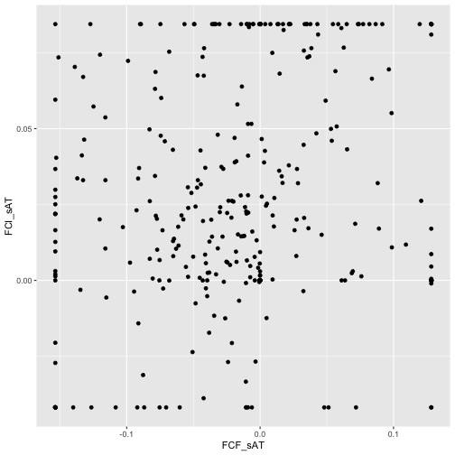

```r
ggplot(data=Dados_2016_N_Fin) + geom_point(aes(x=FCF_sAT, y=FCI_sAT))
```

### Análises Longitudinais (Cross Section) - Exemplo

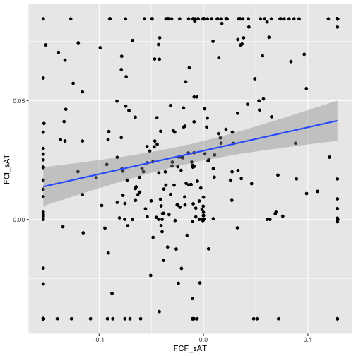

```r
ggplot(data=Dados_2016_N_Fin) + geom_point(aes(x=FCF_sAT, y=FCI_sAT)) + geom_smooth(aes(x=FCF_sAT, y=FCI_sAT), method="lm")
```

### Análises Longitudinais (Cross Section) - Exemplo

```r
Modelo1 <- lm(FCI_sAT ~ FCF_sAT, data=Dados_2016_N_Fin)
summary(Modelo1)
```

```
Call:
lm(formula = FCI_sAT ~ FCF_sAT, data = Dados_2016_N_Fin)

Residuals:
      Min        1Q    Median        3Q       Max
-0.083424 -0.028217 -0.004274  0.037032  0.070656

Coefficients:
            Estimate Std. Error t value Pr(>|t|)
(Intercept)  0.02892    0.00209  13.837  < 2e-16 ***
FCF_sAT      0.09859    0.02631   3.747 0.000211 ***
---
Signif. codes:  0 '***' 0.001 '**' 0.01 '*' 0.05 '.' 0.1 ' ' 1

Residual standard error: 0.03749 on 333 degrees of freedom
Multiple R-squared:  0.04045,   Adjusted R-squared:  0.03757
F-statistic: 14.04 on 1 and 333 DF,  p-value: 0.0002111
```

### Modelos

```r
Modelo2 <- lm(FCI_sAT ~ FCO_sAT, data=Dados_2016_N_Fin)
summary(Modelo2)
```

```
Call:
lm(formula = FCI_sAT ~ FCO_sAT, data = Dados_2016_N_Fin)

Residuals:
      Min        1Q    Median        3Q       Max
-0.091843 -0.022379 -0.002792  0.028042  0.081657

Coefficients:
            Estimate Std. Error t value Pr(>|t|)
(Intercept) 0.020859   0.002167   9.626  < 2e-16 ***
FCO_sAT     0.154237   0.022200   6.948 1.96e-11 ***
---
Signif. codes:  0 '***' 0.001 '**' 0.01 '*' 0.05 '.' 0.1 ' ' 1

Residual standard error: 0.03577 on 333 degrees of freedom
Multiple R-squared:  0.1266,    Adjusted R-squared:  0.124
F-statistic: 48.27 on 1 and 333 DF,  p-value: 1.962e-11
```

### Modelos

```r
Modelo3 <- lm(FCI_sAT ~ FCF_sAT + FCO_sAT, data=Dados_2016_N_Fin)
summary(Modelo3)
```

```
Call:
lm(formula = FCI_sAT ~ FCF_sAT + FCO_sAT, data = Dados_2016_N_Fin)

Residuals:
      Min        1Q    Median        3Q       Max
-0.077753 -0.020439 -0.002698  0.020152  0.157445

Coefficients:
            Estimate Std. Error t value Pr(>|t|)
(Intercept) 0.018387   0.001784   10.30   <2e-16 ***
FCF_sAT     0.336632   0.026215   12.84   <2e-16 ***
FCO_sAT     0.339069   0.023184   14.62   <2e-16 ***
---
Signif. codes:  0 '***' 0.001 '**' 0.01 '*' 0.05 '.' 0.1 ' ' 1

Residual standard error: 0.02928 on 332 degrees of freedom
Multiple R-squared:  0.4164,    Adjusted R-squared:  0.4129
F-statistic: 118.5 on 2 and 332 DF,  p-value: < 2.2e-16
```

### Modelos

```r
Modelo4 <- lm(FCI_sAT ~ FCF_sAT + FCO_sAT + log(AT), data=Dados_2016_N_Fin)
summary(Modelo4)
```

```
Call:
lm(formula = FCI_sAT ~ FCF_sAT + FCO_sAT + log(AT), data = Dados_2016_N_Fin)

Residuals:
      Min        1Q    Median        3Q       Max
-0.079461 -0.017515 -0.002606  0.018703  0.157558

Coefficients:
              Estimate Std. Error t value Pr(>|t|)
(Intercept) -0.0061455  0.0078603  -0.782   0.4349
FCF_sAT      0.3421913  0.0259157  13.204   <2e-16 ***
FCO_sAT      0.3123520  0.0243414  12.832   <2e-16 ***
log(AT)      0.0018727  0.0005848   3.202   0.0015 **
---
Signif. codes:  0 '***' 0.001 '**' 0.01 '*' 0.05 '.' 0.1 ' ' 1

Residual standard error: 0.02888 on 331 degrees of freedom
Multiple R-squared:  0.434, Adjusted R-squared:  0.4288
F-statistic: 84.59 on 3 and 331 DF,  p-value: < 2.2e-16
```

### Modelos

```r
Dados_2016_N_Fin <- Dados_2016_N_Fin %>% mutate(Qtobin = (AT - Pat_Liq + ValorMercado) / AT  )
```

### Modelos

```r
Modelo5 <- lm(FCI_sAT ~ FCF_sAT + FCO_sAT + log(AT) + Qtobin, data=Dados_2016_N_Fin)
summary(Modelo5)
```

```
Call:
lm(formula = FCI_sAT ~ FCF_sAT + FCO_sAT + log(AT) + Qtobin,
    data = Dados_2016_N_Fin)

Residuals:
      Min        1Q    Median        3Q       Max
-0.074279 -0.017908 -0.000091  0.017780  0.086963

Coefficients:
              Estimate Std. Error t value Pr(>|t|)
(Intercept) -1.720e-02  1.426e-02  -1.206   0.2288
FCF_sAT      3.555e-01  2.949e-02  12.057   <2e-16 ***
FCO_sAT      3.525e-01  2.690e-02  13.103   <2e-16 ***
log(AT)      2.443e-03  9.708e-04   2.516   0.0125 *
Qtobin       6.167e-05  2.212e-04   0.279   0.7807
---
Signif. codes:  0 '***' 0.001 '**' 0.01 '*' 0.05 '.' 0.1 ' ' 1

Residual standard error: 0.02798 on 251 degrees of freedom
  (79 observations deleted due to missingness)
Multiple R-squared:  0.4842,    Adjusted R-squared:  0.476
F-statistic:  58.9 on 4 and 251 DF,  p-value: < 2.2e-16
```

### Modelos

```r
vif(Modelo5)
```

```
 FCF_sAT  FCO_sAT  log(AT)   Qtobin
1.426780 1.506098 1.238096 1.164245
```

```r
bptest(Modelo5)
```

```
    studentized Breusch-Pagan test

data:  Modelo5
BP = 7.4911, df = 4, p-value = 0.1121
```

```r
jarque.bera.test(Modelo5$residuals)
```

```
    Jarque Bera Test

data:  Modelo5$residuals
X-squared = 1.1059, df = 2, p-value = 0.5753
```

### Variáveis Dummy

Quando precisamos controlar o efeito diferencial de uma ou mais categorias, utilizamos variáveis do tipo dummy, que assumem valor = 1 quando determinada condição ocorre, e 0 quando a condição não ocorre. No exemplo, criamos uma variável dummy que é igual a 1 quando o payout é maior do que 0,5 do lucro

```r
Dados_2016_N_Fin <- Dados_2016_N_Fin %>%
  mutate(Payout = -DivPagto / LucroLiq)
summary(Dados_2016_N_Fin$Payout)
```

```
     Min.   1st Qu.    Median      Mean   3rd Qu.      Max.      NA's
  -7.7098    0.0000    0.0000    5.0660    0.3445 1512.5758        15
```

### Variáveis Dummy

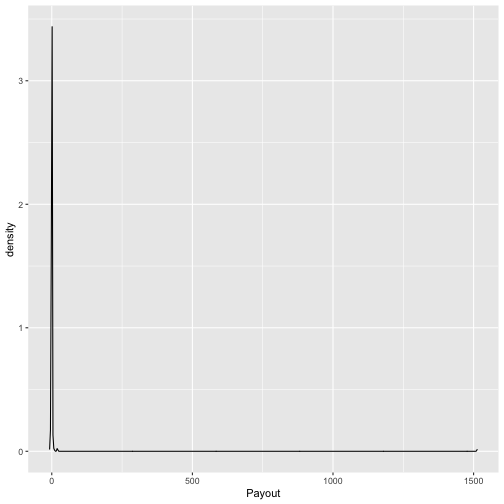

```r
ggplot(data=Dados_2016_N_Fin) + geom_density(aes(x=Payout))
```

### Variáveis Dummy

```r
Dados_2016_N_Fin <- Dados_2016_N_Fin %>%
  filter(Payout>0) %>%
  mutate(PayoutAdj = ifelse(Payout<1,Payout,1))
```

### Variáveis Dummy

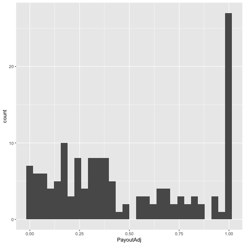

```r
ggplot(data=Dados_2016_N_Fin) + geom_histogram(aes(x=PayoutAdj))
```

### Variáveis Dummy

```r
Dados_2016_N_Fin <- Dados_2016_N_Fin %>%
mutate(D_Moda = as.numeric(PayoutAdj>0.50))
table(Dados_2016_N_Fin$D_Moda)
```

```
 0  1
85 59
```

### Variáveis Dummy

```r
Modelo6 <- lm(FCI_sAT ~ FCF_sAT + FCO_sAT + log(AT) + Qtobin + D_Moda, data=Dados_2016_N_Fin)
summary(Modelo6)
```

```
Call:
lm(formula = FCI_sAT ~ FCF_sAT + FCO_sAT + log(AT) + Qtobin +
    D_Moda, data = Dados_2016_N_Fin)

Residuals:
      Min        1Q    Median        3Q       Max
-0.073166 -0.018367  0.000393  0.018722  0.078797

Coefficients:
             Estimate Std. Error t value Pr(>|t|)
(Intercept) -0.023218   0.025143  -0.923    0.358
FCF_sAT      0.356978   0.049317   7.238 5.50e-11 ***
FCO_sAT      0.376255   0.043098   8.730 2.33e-14 ***
log(AT)      0.002515   0.001596   1.576    0.118
Qtobin       0.004235   0.003444   1.230    0.221
D_Moda      -0.007324   0.005608  -1.306    0.194
---
Signif. codes:  0 '***' 0.001 '**' 0.01 '*' 0.05 '.' 0.1 ' ' 1

Residual standard error: 0.02812 on 115 degrees of freedom
  (23 observations deleted due to missingness)
Multiple R-squared:  0.4997,    Adjusted R-squared:  0.4779
F-statistic: 22.97 on 5 and 115 DF,  p-value: 6.26e-16
```

### Variáveis Dummy

```r
Dados_2016_N_Fin <- Dados_2016_N_Fin %>%
mutate(D_IBOV = as.numeric(Particip_no_indice>0))
table(Dados_2016_N_Fin$D_IBOV)
```

```
  0   1
108  36
```

### Variáveis Dummy

```r
Modelo7 <- lm(FCI_sAT ~ FCF_sAT + FCO_sAT + Qtobin + D_IBOV, data=Dados_2016_N_Fin)
summary(Modelo7)
```

```
Call:
lm(formula = FCI_sAT ~ FCF_sAT + FCO_sAT + Qtobin + D_IBOV, data = Dados_2016_N_Fin)

Residuals:
      Min        1Q    Median        3Q       Max
-0.070697 -0.017910 -0.000659  0.018119  0.080351

Coefficients:
            Estimate Std. Error t value Pr(>|t|)
(Intercept) 0.012269   0.005580   2.199   0.0299 *
FCF_sAT     0.379517   0.046380   8.183 4.01e-13 ***
FCO_sAT     0.382341   0.042813   8.930 7.55e-15 ***
Qtobin      0.002458   0.003501   0.702   0.4839
D_IBOV      0.009607   0.005724   1.678   0.0960 .
---
Signif. codes:  0 '***' 0.001 '**' 0.01 '*' 0.05 '.' 0.1 ' ' 1

Residual standard error: 0.02811 on 116 degrees of freedom
  (23 observations deleted due to missingness)
Multiple R-squared:  0.4958,    Adjusted R-squared:  0.4784
F-statistic: 28.51 on 4 and 116 DF,  p-value: < 2.2e-16
```

### Regressão Logística

Em 1846, as famílias Donner e Reed deixaram Springfield, Illinois, para a Califórnia por carroça coberta. Em julho, o Bando Donner, como o grupo se tornou conhecido, chegou a Fort Bridger, Wyoming. Os seus líderes decidiram tentar um novo e não testado trajeto para o Vale de Sacramento.

### Regressão Logística

Tendo atingido o tamanho total de 87 pessoas e 20 carroças, o Bando teve sua viagem atrasada por uma difícil travessia da Cordilheira Wasatch e novamente no cruzamento do deserto a oeste do Great Salt Lake. O grupo ficou preso nas montanhas do leste da Serra Nevada, quando a região foi atingida por fortes nevascas no final de outubro. No momento em que o último sobrevivente foi resgatado em 21 de abril de 1847, 40 dos 87 membros morreram por fome e exposição ao frio extremo.

### Regressão Logística

```r
library(openintro)
data(COL)
library(Sleuth3)
donner <- case2001
table(donner$Status, donner$Sex)
```

```
           Female Male
  Died          5   20
  Survived     10   10
```

### Regressão Logística

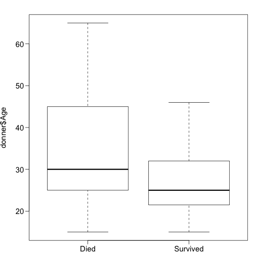

```r
par(mar=c(2,4,2,1), las=1, mgp=c(3,0.7,0), cex.lab = 1.25, cex.axis = 1.25)
boxplot(donner$Age ~ donner$Status)
```

### Regressão Logística

```r
g1<-glm(Status~Age, data=donner, family=binomial)
summary(g1)
```

```
Call:
glm(formula = Status ~ Age, family = binomial, data = donner)

Deviance Residuals:
    Min       1Q   Median       3Q      Max
-1.5401  -1.1594  -0.4651   1.0842   1.7283

Coefficients:
            Estimate Std. Error z value Pr(>|z|)
(Intercept)  1.81852    0.99937   1.820   0.0688 .
Age         -0.06647    0.03222  -2.063   0.0391 *
---
Signif. codes:  0 '***' 0.001 '**' 0.01 '*' 0.05 '.' 0.1 ' ' 1

(Dispersion parameter for binomial family taken to be 1)

    Null deviance: 61.827  on 44  degrees of freedom
Residual deviance: 56.291  on 43  degrees of freedom
AIC: 60.291

Number of Fisher Scoring iterations: 4
```

### Regressão Logística

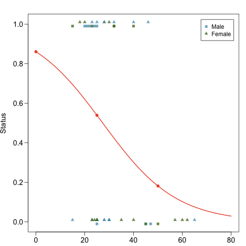

### Regressão Logística

```r
g<-glm(Status~Age+Sex, data=donner, family=binomial)
summary(g)
```

```
Call:
glm(formula = Status ~ Age + Sex, family = binomial, data = donner)

Deviance Residuals:
    Min       1Q   Median       3Q      Max
-1.7445  -1.0441  -0.3029   0.8877   2.0472

Coefficients:
            Estimate Std. Error z value Pr(>|z|)
(Intercept)  3.23041    1.38686   2.329   0.0198 *
Age         -0.07820    0.03728  -2.097   0.0359 *
SexMale     -1.59729    0.75547  -2.114   0.0345 *
---
Signif. codes:  0 '***' 0.001 '**' 0.01 '*' 0.05 '.' 0.1 ' ' 1

(Dispersion parameter for binomial family taken to be 1)

    Null deviance: 61.827  on 44  degrees of freedom
Residual deviance: 51.256  on 42  degrees of freedom
AIC: 57.256

Number of Fisher Scoring iterations: 4
```

### Regressão Logística

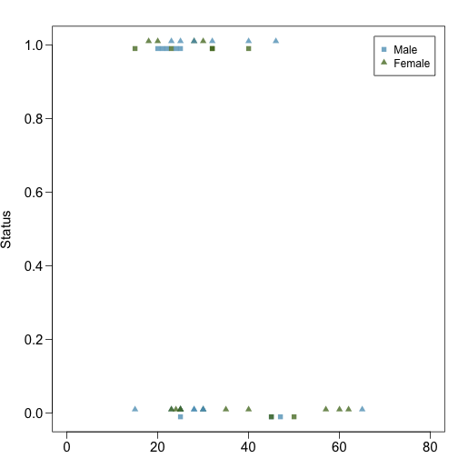

### Regressão Logística

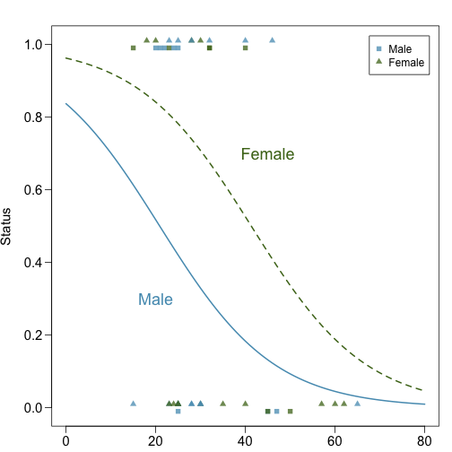

### Regressão Logística

- Linearidade não é evidente.
- Podemos tratar pagadores e não pagadores como sucessos e fracassos advindos de uma distribuição binomial.
- A probabilidade de sucesso é dada pela transformação de um modelo linear a partir de um conjunto de previsores.

### Regressão Logística

Para isso, utilizamos modelos do tipo Generalized linear models (GLMs), dos quais a regressão logística é apenas um exemplo.

Todos os GLM tem as seguintes características:

- Uma distribuição de probabilidade que descreve a variável de resposta
- Um modelo linear do tipo: \( \eta = \beta_0+\beta_1 X_1 + \cdots + \beta_n X_n \)
- Uma função de link que relaciona o modelo linear aos parâmetros da distribuição da variável de resposta

### Regressão Logística

- A regressão logística é um tipo de GLM que pode ser usado para modelar uma variável binária e categórica usando previsores numéricos e categóricos.
- Assumimos a distribuição binomial da variável de resposta, e então queremos modelar \( p \) , a probabilidade de sucesso dado um conjunto de previsores.
- Na função Logit, nossa variável de resposta é o log dos odds.

\[ logit(p) = \log\left(\frac{p}{1-p}\right),\text{ for $0\le p \le 1$} \]

### Regressão Logística

Para estimar a probabilidade de um determinado tomador de crédito virar não pagador:

\[ p_i = \frac{\exp(\beta_0+\beta_1 x_{1,i} + \cdots + \beta_n x_{n,i})}{1+\exp(\beta_0+\beta_1 x_{1,i} + \cdots + \beta_n x_{n,i})} \]

No R, estimamos essa probabilidade por meio da função *predict*.

### Regressão Logistica - Exemplo com dados de 2016

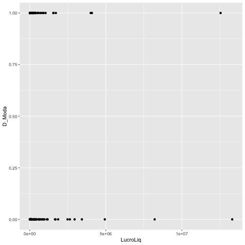

```r
ggplot(data=Dados_2016_N_Fin) + geom_point(aes(x=LucroLiq, y=D_Moda))
```

### Regressão Logistica

```r
BaseLogit <- Dados_2016_N_Fin %>% select(D_Moda, TAM, ALAV, Qtobin,FCO_sAT,ROE_ini,Setor_economatica,FCI_sAT,FCF_sAT)
BaseLogit <- BaseLogit[complete.cases(BaseLogit),]
table(BaseLogit$D_Moda)
```

```
 0  1
65 53
```

### Regressão Logistica

```r
logit1 <- glm(D_Moda ~ TAM+ALAV+Qtobin+ROE_ini, data = BaseLogit, family = binomial(link = "logit"))
summary(logit1)
```

```
Call:
glm(formula = D_Moda ~ TAM + ALAV + Qtobin + ROE_ini, family = binomial(link = "logit"),
    data = BaseLogit)

Deviance Residuals:
    Min       1Q   Median       3Q      Max
-1.9373  -1.0255  -0.7851   1.2146   1.5568

Coefficients:
            Estimate Std. Error z value Pr(>|z|)
(Intercept) -2.01791    1.90624  -1.059   0.2898
TAM          0.02014    0.12454   0.162   0.8715
ALAV         0.28969    0.14565   1.989   0.0467 *
Qtobin       0.66526    0.30166   2.205   0.0274 *
ROE_ini     -0.01435    0.01046  -1.371   0.1703
---
Signif. codes:  0 '***' 0.001 '**' 0.01 '*' 0.05 '.' 0.1 ' ' 1

(Dispersion parameter for binomial family taken to be 1)

    Null deviance: 162.36  on 117  degrees of freedom
Residual deviance: 152.50  on 113  degrees of freedom
AIC: 162.5

Number of Fisher Scoring iterations: 4
```

### Regressão Logit

```r
with(logit1, pchisq(null.deviance - deviance, df.null - df.residual, lower.tail = FALSE))
```

```
[1] 0.04283494
```

p-valor da hipótese nula que nosso modelo é pior que um modelo vazio.

### Regressão Logit

```r
previsoes <- predict(logit1, type="response")
predict <- ifelse(predict(logit1, type="response")>.5, 1, 0)
xtabs(~predict+BaseLogit$D_Moda)
```

```
       BaseLogit$D_Moda
predict  0  1
      0 52 33
      1 13 20
```

### Regressão Logit

```r
anova(logit1, test="Chisq")
```

```
Analysis of Deviance Table

Model: binomial, link: logit

Response: D_Moda

Terms added sequentially (first to last)

        Df Deviance Resid. Df Resid. Dev Pr(>Chi)
NULL                      117     162.36
TAM      1   0.6226       116     161.74  0.43008
ALAV     1   3.4726       115     158.26  0.06239 .
Qtobin   1   3.8763       114     154.39  0.04897 *
ROE_ini  1   1.8895       113     152.50  0.16925
---
Signif. codes:  0 '***' 0.001 '**' 0.01 '*' 0.05 '.' 0.1 ' ' 1
```

### Regressão Logística

```r
library(pscl)
pR2(logit1)
```

```
fitting null model for pseudo-r2
```

```
         llh      llhNull           G2     McFadden         r2ML         r2CU
-76.24962996 -81.18014173   9.86102353   0.06073544   0.08017146   0.10726763
```

### Regressão Logística

Exercício: Considerando as variáveis disponíveis, tentar identificar um modelo melhor, com maior capacidade preditiva.

### Regressão Logística

```r
library(tidyverse)  # data manipulation and visualization
library(modelr)     # provides easy pipeline modeling functions
library(broom)      # helps to tidy up model outputs
library(ISLR)
```

### Regressão Logística

```r
# Load data
(default <- as_tibble(ISLR::Default))
```

```
# A tibble: 10,000 x 4
   default student balance income
   <fct>   <fct>     <dbl>  <dbl>
 1 No      No         730. 44362.
 2 No      Yes        817. 12106.
 3 No      No        1074. 31767.
 4 No      No         529. 35704.
 5 No      No         786. 38463.
 6 No      Yes        920.  7492.
 7 No      No         826. 24905.
 8 No      Yes        809. 17600.
 9 No      No        1161. 37469.
10 No      No           0  29275.
# … with 9,990 more rows
```

### Regressão Logística

```r
set.seed(123)
sample <- sample(c(TRUE, FALSE), nrow(default), replace = T, prob = c(0.6,0.4))
train <- default[sample, ]
test <- default[!sample, ]
```

### Regressão Logística

```r
model1 <- glm(default ~ balance, family = "binomial", data = train)
summary(model1)
```

```
Call:
glm(formula = default ~ balance, family = "binomial", data = train)

Deviance Residuals:
    Min       1Q   Median       3Q      Max
-2.2905  -0.1395  -0.0528  -0.0189   3.3346

Coefficients:
              Estimate Std. Error z value Pr(>|z|)
(Intercept) -1.101e+01  4.887e-01  -22.52   <2e-16 ***
balance      5.669e-03  2.949e-04   19.22   <2e-16 ***
---
Signif. codes:  0 '***' 0.001 '**' 0.01 '*' 0.05 '.' 0.1 ' ' 1

(Dispersion parameter for binomial family taken to be 1)

    Null deviance: 1723.03  on 6046  degrees of freedom
Residual deviance:  908.69  on 6045  degrees of freedom
AIC: 912.69

Number of Fisher Scoring iterations: 8
```

### Regressão Logística

```r
graf <- default %>%
  mutate(prob = ifelse(default == "Yes", 1, 0)) %>%
  ggplot(aes(balance, prob)) +
  geom_point(alpha = .15) +
  geom_smooth(method = "glm", method.args = list(family = "binomial")) +
  ggtitle("Ajuste do modelo de Regreção Logística") +
  xlab("Saldo") +
  ylab("Probabilidade de Não Pagamento")
```

### Regressão Logística

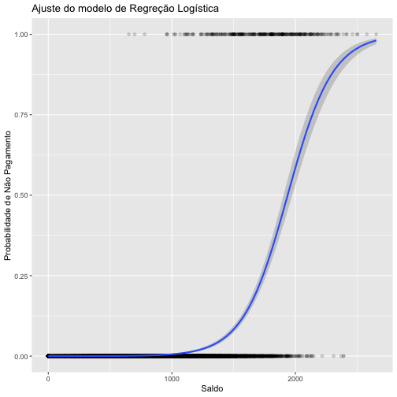

```r
graf
```

### Regressão Logística

```r
predict(model1, data.frame(balance = c(1000, 2000)), type = "response")
```

```
          1           2
0.004785057 0.582089269
```

### Regressão Logística

```r
model2 <- glm(default ~ balance + income + student, family = "binomial", data = train)
tidy(model2)
```

```
# A tibble: 4 x 5
  term            estimate std.error statistic  p.value
  <chr>              <dbl>     <dbl>     <dbl>    <dbl>
1 (Intercept) -10.9        0.648       -16.8   1.47e-63
2 balance       0.00591    0.000310     19.0   7.90e-81
3 income       -0.00000501 0.0000108    -0.465 6.42e- 1
4 studentYes   -0.809      0.313        -2.58  9.78e- 3
```

### Regressão Logística

```r
new.df <- tibble(balance = 1500, income = 40, student = c("Yes", "No"))
predict(model2, new.df, type = "response")
```

```
         1          2
0.05437124 0.11440288
```

### Regressão Logística

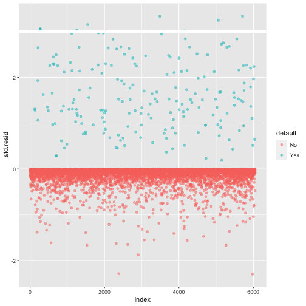

```r
model1_data <- augment(model1) %>%
  mutate(index = 1:n())

ggplot(model1_data, aes(index, .std.resid, color = default)) +
  geom_point(alpha = .5) +
  geom_ref_line(h = 3)
```

### Regressão Logística

```r
model1_data %>%
  filter(abs(.std.resid) > 3)
```

```
# A tibble: 8 x 10
  default balance .fitted .se.fit .resid    .hat .sigma .cooksd .std.resid index
  <fct>     <dbl>   <dbl>   <dbl>  <dbl>   <dbl>  <dbl>   <dbl>      <dbl> <int>
1 Yes       1119.   -4.66   0.175   3.06 2.84e-4  0.386  0.0151       3.06   271
2 Yes       1119.   -4.66   0.175   3.06 2.84e-4  0.386  0.0151       3.06   272
3 Yes       1135.   -4.57   0.171   3.03 2.97e-4  0.386  0.0144       3.03  1253
4 Yes       1067.   -4.96   0.189   3.15 2.46e-4  0.386  0.0175       3.15  1542
5 Yes        961.   -5.56   0.216   3.33 1.80e-4  0.385  0.0232       3.33  3488
6 Yes       1144.   -4.52   0.169   3.01 3.03e-4  0.386  0.0140       3.01  4142
7 Yes       1013.   -5.26   0.203   3.25 2.11e-4  0.385  0.0203       3.25  5058
8 Yes        962.   -5.55   0.216   3.33 1.80e-4  0.385  0.0232       3.33  5709
```

### Regressão Logística

```r
test.predicted.m1 <- predict(model1, newdata = test, type = "response")
test.predicted.m2 <- predict(model2, newdata = test, type = "response")
```

### Regressão Logística

```r
list(
  model1 = table(test$default, test.predicted.m1 > 0.5) %>% prop.table() %>% round(3),
  model2 = table(test$default, test.predicted.m2 > 0.5) %>% prop.table() %>% round(3)
)
```

```
$model1

      FALSE  TRUE
  No  0.962 0.003
  Yes 0.025 0.010

$model2

      FALSE  TRUE
  No  0.963 0.003
  Yes 0.026 0.009
```

### Regressão Logística

Cada quadrante da tabela tem um significado importante. Nesse caso, o “Não” e o “Sim” nas linhas representam se os clientes pagaram ou não. O “FALSO” e o “VERDADEIRO” nas colunas representam se previamos se os clientes entrariam em default ou não.

```r
table(test$default, test.predicted.m1 > 0.5)
```

```
      FALSE TRUE
  No   3803   12
  Yes    98   40
```

```r
table(test$default, test.predicted.m2 > 0.5)
```

```
      FALSE TRUE
  No   3805   10
  Yes   101   37
```

### Regressão Logística

Exemplo de credit scoring com dados reais

```r
#Lendo a base de dados Credit German:
library(readxl)
exemplo1 <- read_excel("exemplo1.xlsx")
```

### Regressão Logística

```r
exemplo1$classe<-as.factor(ifelse(exemplo1$Y == 0, "Bom", "Ruim"))
summary(exemplo1)
```

```
   status_1         tempo_financiamento     idade             Y
 Length:1000        Min.   : 4.0        Min.   :19.00   Min.   :0.0
 Class :character   1st Qu.:12.0        1st Qu.:27.00   1st Qu.:0.0
 Mode  :character   Median :18.0        Median :33.00   Median :0.0
                    Mean   :20.9        Mean   :35.55   Mean   :0.3
                    3rd Qu.:24.0        3rd Qu.:42.00   3rd Qu.:1.0
                    Max.   :72.0        Max.   :75.00   Max.   :1.0
  classe
 Bom :700
 Ruim:300
```

#Vendo a classificação dos clientes da base de dados:

```r
table(exemplo1$status_1)
```

```
            alto            baixo         negativo sem cta corrente
              63              269              274              394
```

```r
table(exemplo1$Y)
```

```
  0   1
700 300
```

### Regressão Logística

```r
require(caret)
# gera amostra fixando os casos
set.seed(1111)
# Amostra de treino e amostra de teste
indice.treino <- createDataPartition(y=exemplo1$Y, p=0.70, list=FALSE)
treino = exemplo1[indice.treino, ]
teste = exemplo1[-indice.treino, ]
table(treino$classe)
```

```
 Bom Ruim
 489  211
```

```r
table(teste$classe)
```

```
 Bom Ruim
 211   89
```

### Regressão Logística

MODELO 1 base treino

```r
reg_log1 <- (glm(Y ~
                status_1
              + tempo_financiamento
              + idade,
              family=binomial(link="logit"), data=treino))
summary(reg_log1)
```

```
Call:
glm(formula = Y ~ status_1 + tempo_financiamento + idade, family = binomial(link = "logit"),
    data = treino)

Deviance Residuals:
    Min       1Q   Median       3Q      Max
-1.6427  -0.8416  -0.4838   0.9671   2.3284

Coefficients:
                          Estimate Std. Error z value Pr(>|z|)
(Intercept)              -1.506384   0.472121  -3.191  0.00142 **
status_1baixo             0.559825   0.382495   1.464  0.14330
status_1negativo          1.149330   0.376781   3.050  0.00229 **
status_1sem cta corrente -0.901132   0.396179  -2.275  0.02293 *
tempo_financiamento       0.039006   0.007410   5.264 1.41e-07 ***
idade                    -0.012771   0.008282  -1.542  0.12306
---
Signif. codes:  0 '***' 0.001 '**' 0.01 '*' 0.05 '.' 0.1 ' ' 1

(Dispersion parameter for binomial family taken to be 1)

    Null deviance: 856.90  on 699  degrees of freedom
Residual deviance: 731.63  on 694  degrees of freedom
AIC: 743.63

Number of Fisher Scoring iterations: 4
```

### Regressão Logística

MODELO 2 base treino

```r
reg_log2 <- (glm(Y ~
                status_1
              + tempo_financiamento,
              family=binomial(link="logit"), data=treino))
summary(reg_log2)
```

```
Call:
glm(formula = Y ~ status_1 + tempo_financiamento, family = binomial(link = "logit"),
    data = treino)

Deviance Residuals:
    Min       1Q   Median       3Q      Max
-1.6481  -0.8233  -0.4679   0.9798   2.2573

Coefficients:
                          Estimate Std. Error z value Pr(>|z|)
(Intercept)              -1.962088   0.372849  -5.262 1.42e-07 ***
status_1baixo             0.590333   0.381598   1.547  0.12186
status_1negativo          1.166812   0.376222   3.101  0.00193 **
status_1sem cta corrente -0.890867   0.395661  -2.252  0.02435 *
tempo_financiamento       0.038668   0.007399   5.226 1.73e-07 ***
---
Signif. codes:  0 '***' 0.001 '**' 0.01 '*' 0.05 '.' 0.1 ' ' 1

(Dispersion parameter for binomial family taken to be 1)

    Null deviance: 856.90  on 699  degrees of freedom
Residual deviance: 734.06  on 695  degrees of freedom
AIC: 744.06

Number of Fisher Scoring iterations: 4
```

### Regressão Logística

Diagnóstico

```r
require(blorr)
blr_rsq_mcfadden_adj(reg_log2)
```

```
[1] 0.1316849
```

```r
blr_rsq_nagelkerke(reg_log2)
```

```
[1] 0.2279796
```

### Regressão Logística

Diagnóstico

```r
require(ROCR)
pred.Teste <- predict(reg_log2,teste, type = "response")
Teste_v2 <- cbind(teste,pred.Teste)
pred.val <- prediction(pred.Teste ,Teste_v2$Y)
# calculo da auc (area under the curve)
auc <- performance(pred.val,"auc")
auc <- auc@y.values[[1]]
auc
```

```
[1] 0.7318547
```

### Regressão Logística

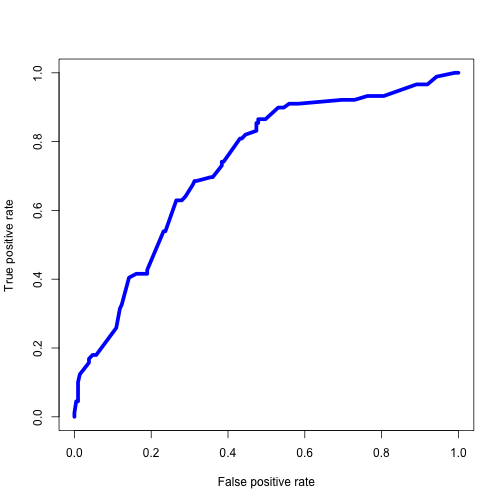

```r
# Plota curva ROC
performance <- performance(pred.val, "tpr", "fpr")
plot(performance, col = "blue", lwd = 5)
```

### Regressão Logística

```r
#confusion matrix com ponto de corte em 50%
table(teste$Y, pred.Teste > 0.5)
```

```
    FALSE TRUE
  0   185   26
  1    60   29
```

```r
#confusion matrix com ponto de corte em 40%
table(teste$Y, pred.Teste > 0.4)
```

```
    FALSE TRUE
  0   162   49
  1    41   48
```

```r
#confusion matrix com ponto de corte em 35%
table(teste$Y, pred.Teste > 0.35)
```

```
    FALSE TRUE
  0   144   67
  1    28   61
```

### Exercício Final

```r
require(evtree)
data("GermanCredit")
summary(GermanCredit)
```

```
                                        status       duration
 ... < 0 DM                                :274   Min.   : 4.0
 0 <= ... < 200 DM                         :269   1st Qu.:12.0
 ... >= 200 DM / salary for at least 1 year: 63   Median :18.0
 no checking account                       :394   Mean   :20.9
                                                  3rd Qu.:24.0
                                                  Max.   :72.0

                                     credit_history                purpose
 no credits taken/all credits paid back duly: 40    domestic appliances:280
 all credits at this bank paid back duly    : 49    car (new)          :234
 existing credits paid back duly till now   :530    radio/television   :181
 delay in paying off in the past            : 88    car (used)         :103
 critical account/other credits existing    :293    others             : 97
                                                    retraining         : 50
                                                    (Other)            : 55
     amount                            savings            employment_duration
 Min.   :  250   ... < 100 DM              :603   unemployed        : 62
 1st Qu.: 1366   100 <= ... < 500 DM       :103   ... < 1 year      :172
 Median : 2320   500 <= ... < 1000 DM      : 63   1 <= ... < 4 years:339
 Mean   : 3271   ... >= 1000 DM            : 48   4 <= ... < 7 years:174
 3rd Qu.: 3972   unknown/no savings account:183   ... >= 7 years    :253
 Max.   :18424

 installment_rate                          personal_status_sex
 Min.   :1.000    male : divorced/separated          : 50
 1st Qu.:2.000    female : divorced/separated/married:310
 Median :3.000    male : single                      :548
 Mean   :2.973    male : married/widowed             : 92
 3rd Qu.:4.000    female : single                    :  0
 Max.   :4.000

      other_debtors present_residence
 none        :907   Min.   :1.000
 co-applicant: 41   1st Qu.:2.000
 guarantor   : 52   Median :3.000
                    Mean   :2.845
                    3rd Qu.:4.000
                    Max.   :4.000

```

[output cut: 16 more lines]

```
                                                         job
 unemployed/unskilled - non-resident                       : 22
 unskilled - resident                                      :200
 skilled employee/official                                 :630
 management/self-employed/highly qualified employee/officer:148



 people_liable   telephone foreign_worker credit_risk
 Min.   :1.000   no :596   yes:963        good:700
 1st Qu.:1.000   yes:404   no : 37        bad :300
 Median :1.000
 Mean   :1.155
 3rd Qu.:1.000
 Max.   :2.000
```

### Exercício Final

Divisão da Base em grupo de treino e teste

```r
set.seed(111111)
in.train <- createDataPartition(GermanCredit$credit_risk, p=0.8, list=FALSE)
german_credit.train <- GermanCredit[in.train,]
german_credit.test <- GermanCredit[-in.train,]
```

### Exercício Final

Regressão Basica

```r
GermanGeral <- glm(credit_risk ~ ., family = binomial, GermanCredit)
summary(GermanGeral)
```

```
Call:
glm(formula = credit_risk ~ ., family = binomial, data = GermanCredit)

Deviance Residuals:
    Min       1Q   Median       3Q      Max
-2.3410  -0.6994  -0.3752   0.7095   2.6116

Coefficients:
                                                                Estimate
(Intercept)                                                    1.290e-01
status0 <= ... < 200 DM                                       -3.749e-01
status... >= 200 DM / salary for at least 1 year              -9.657e-01
statusno checking account                                     -1.712e+00
duration                                                       2.786e-02
credit_historyall credits at this bank paid back duly          1.434e-01
credit_historyexisting credits paid back duly till now        -5.861e-01
credit_historydelay in paying off in the past                 -8.532e-01
credit_historycritical account/other credits existing         -1.436e+00
purposecar (used)                                             -1.666e+00
purposefurniture/equipment                                    -1.489e+00
purposeradio/television                                       -7.916e-01
purposedomestic appliances                                    -8.916e-01
purposerepairs                                                -5.228e-01
purposeeducation                                              -2.164e-01
purposeretraining                                              3.628e-02
purposebusiness                                               -2.059e+00
purposeothers                                                 -7.401e-01
amount                                                         1.283e-04
savings100 <= ... < 500 DM                                    -3.577e-01
savings500 <= ... < 1000 DM                                   -3.761e-01
savings... >= 1000 DM                                         -1.339e+00
savingsunknown/no savings account                             -9.467e-01
employment_duration.L                                         -4.166e-01
employment_duration.Q                                          1.898e-01
employment_duration.C                                          3.958e-01
employment_duration^4                                          2.651e-01
installment_rate                                               3.301e-01
personal_status_sexfemale : divorced/separated/married        -2.755e-01
personal_status_sexmale : single                              -8.161e-01
personal_status_sexmale : married/widowed                     -3.671e-01
```

[output cut: 163 more lines]

```
jobskilled employee/official
jobmanagement/self-employed/highly qualified employee/officer
people_liable
telephoneyes
foreign_workerno                                              *
---
Signif. codes:  0 '***' 0.001 '**' 0.01 '*' 0.05 '.' 0.1 ' ' 1

(Dispersion parameter for binomial family taken to be 1)

    Null deviance: 1221.73  on 999  degrees of freedom
Residual deviance:  895.82  on 951  degrees of freedom
AIC: 993.82

Number of Fisher Scoring iterations: 5
```

### Exercício Final

Diagnóstico

```r
prob.GermanGeral <- predict(GermanGeral, type = "response")
GermanCredit <- GermanCredit %>% mutate(credit_risk_response = ifelse(credit_risk=="good",0,1))
predicted.GermanGeral <- prob.GermanGeral > 0.50
predicted.GermanGeral <- as.numeric(predicted.GermanGeral)
table(GermanCredit$credit_risk_response, predicted.GermanGeral, dnn = c("Truth", "Predicted"))
```

```
     Predicted
Truth   0   1
    0 626  74
    1 140 160
```

```r
blr_rsq_mcfadden_adj(GermanGeral)
```

```
[1] 0.1865478
```

```r
blr_rsq_nagelkerke(GermanGeral)
```

```
[1] 0.3943548
```

### Exercício Final

Sample - Amostra para melhorar capacidade de generalização

```r
GermanInSample <- glm(credit_risk ~ ., family = binomial, german_credit.train)
summary(GermanInSample)
```

```
Call:
glm(formula = credit_risk ~ ., family = binomial, data = german_credit.train)

Deviance Residuals:
    Min       1Q   Median       3Q      Max
-2.3573  -0.6740  -0.3421   0.6854   2.6023

Coefficients:
                                                                Estimate
(Intercept)                                                    4.922e-01
status0 <= ... < 200 DM                                       -2.698e-01
status... >= 200 DM / salary for at least 1 year              -1.028e+00
statusno checking account                                     -1.957e+00
duration                                                       2.824e-02
credit_historyall credits at this bank paid back duly          3.589e-01
credit_historyexisting credits paid back duly till now        -2.670e-01
credit_historydelay in paying off in the past                 -8.073e-01
credit_historycritical account/other credits existing         -1.128e+00
purposecar (used)                                             -1.692e+00
purposefurniture/equipment                                    -1.295e+00
purposeradio/television                                       -9.453e-01
purposedomestic appliances                                    -9.891e-01
purposerepairs                                                -8.378e-02
purposeeducation                                              -1.799e-01
purposeretraining                                             -1.781e-01
purposebusiness                                               -1.555e+01
purposeothers                                                 -6.093e-01
amount                                                         1.286e-04
savings100 <= ... < 500 DM                                    -7.369e-01
savings500 <= ... < 1000 DM                                   -1.877e-01
savings... >= 1000 DM                                         -1.597e+00
savingsunknown/no savings account                             -1.064e+00
employment_duration.L                                         -1.986e-01
employment_duration.Q                                         -1.103e-01
employment_duration.C                                          5.941e-01
employment_duration^4                                          2.359e-01
installment_rate                                               3.585e-01
personal_status_sexfemale : divorced/separated/married        -4.471e-01
personal_status_sexmale : single                              -7.855e-01
personal_status_sexmale : married/widowed                     -3.845e-01
```

[output cut: 163 more lines]

```
jobskilled employee/official
jobmanagement/self-employed/highly qualified employee/officer
people_liable
telephoneyes
foreign_workerno                                              *
---
Signif. codes:  0 '***' 0.001 '**' 0.01 '*' 0.05 '.' 0.1 ' ' 1

(Dispersion parameter for binomial family taken to be 1)

    Null deviance: 977.38  on 799  degrees of freedom
Residual deviance: 692.52  on 751  degrees of freedom
AIC: 790.52

Number of Fisher Scoring iterations: 14
```

### Exercício Final

Diagnóstico

```r
prob.GermanInSample <- predict(GermanInSample, type = "response")
german_credit.train <- german_credit.train %>% mutate(credit_risk_response = ifelse(credit_risk=="good",0,1))
predicted.GermanInSample <- prob.GermanInSample > 0.50
predicted.GermanInSample <- as.numeric(predicted.GermanInSample)
table(german_credit.train$credit_risk_response, predicted.GermanInSample, dnn = c("Truth", "Predicted"))
```

```
     Predicted
Truth   0   1
    0 491  69
    1 104 136
```

```r
blr_rsq_mcfadden_adj(GermanInSample)
```

```
[1] 0.1911912
```

```r
blr_rsq_nagelkerke(GermanInSample)
```

```
[1] 0.4247762
```

### Exercício Final

No grupo de treino (in sample)

```r
pred.Train <- predict(GermanInSample,german_credit.train , type = "response")
german_credit.train <- german_credit.train %>% mutate(credit_risk_response = ifelse(credit_risk=="good",0,1))
Train_v2 <- cbind(german_credit.train,pred.Train)
pred.val <- prediction(pred.Train ,Train_v2$credit_risk_response)
# calculo da auc (area under the curve)
auc <- performance(pred.val,"auc")
auc <- auc@y.values[[1]]
auc
```

```
[1] 0.8468452
```

### Exercício Final

No grupo de treino (in sample)

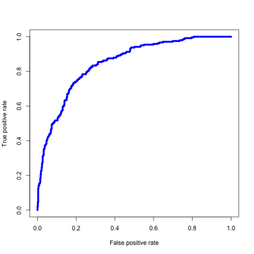

```r
# Plota curva ROC
performance <- performance(pred.val, "tpr", "fpr")
plot(performance, col = "blue", lwd = 5)
```

### Exercício Final

Estimar modelo com seleção de variáveis